# Tutorial Diagram de Arcos

## O que é um Diagrama de Arcos ?

É uma representação gráfica unidimensional para visualizar conexões entre um conjunto de entidades. A ideia principal é exibir os nós ao longo de um eixo, enquanto as conexões entre os nós são representadas com arcos.

## Arcdiagram

Arcdiagram é um pacote minimalista que fornece uma função básica para plotar diagramas de arco bonitos em R.

## Instalação do pacote

```r
#instalando devtools
install.packages("devtools")

#Carregadno load devtools
library(devtools)

#Fazendo download 'arcdiagram' usando 'install_github'

remotes::install_github("gastonstat/arcdiagram")

#carregadno arcdiagram
library(arcdiagram)
```

## Uso básico do pacote Arcdiagram

A estrutura é simples e consiste em uma função principal arcplot(), e uma função acessória xynodes(). Arcplot funciona da seguinte maneira, pega um objeto “edgelist” e plota as arestas como arcos. Edgelist é apenas uma matriz de duas colunas que fornece uma lista de arestas para um gráfico.

## Função arcplot()

Existem de diversos parâmetros da função arcplot(). O parâmetro principal é o edgelist, que é uma matriz de duas colunas com as arestas do gráfico, este é um parâmetro que obrigatoriamente deve ser fornecido, os demais são opcionais.

### Argumentos dos arcos:

Os arcos são plotados pelo arcplot() usando a função lines() internamente. Isto significa que os argumentos relacionados ao arco são basicamente os argumentos por trás das linhas ():

*`col.arcs`*: cor dos arcos

*`lwd.arcs`*: largura das linhas dos arcos

*`lty`*: tipo de linha dos arcos

*`ljoin`*: estilo de junção de linha para os arcos

### Argumentos dos símbolos dos nós:

Os símbolos dos nós são plotados por arcplot() usando a função points() internamente. O que isso significa é que os argumentos dos símbolos dos nós são basicamente os argumentos que points() usa:

*`show.nodes`*: indica se deseja mostrar símbolo nos nós

*`pch.nodes`*: indica o símbolo a ser usado ao plotar nós

*`col.nodes`*: cor dos símbolos dos nós

*`bg.nodes`*: cor de preenchimento para os símbolos dos nós

*`lwd.nodes`*: largura da linha para desenhar símbolos de nós

### Argumentos dos rótulos dos nós:

os rótulos dos nós são plotados por arcplot() usando o mtext(), função interna. Os argumentos dos rótulos dos nós estão relacionados aos argumentos por trás de mtext ():

*`show.labels`*:indica se os rótulos dos nós devem ser mostrados

*`labels`*: vetor de caracteres com rótulos para os nós

*`col.labels`*: cor dos rótulos dos nós

*`las`*: numérico em 0,1,2,3 determina o estilo dos rótulos dos eixos

*`font`*: fonte usada para rótulos dos nós

### Argumentos adicionais:

Além dos argumentos anteriores, há alguns outros parâmetros no arcplot() que controlam a ordem dos nós e a orientação do layout:

*`sorted`*: lógico para indicar se os nós devem ser sorteado

*`decreasing`*: lógico para indicar o tipo de classificação

*`ordering`*: vetor numérico opcional que fornece a ordem dos nós

*`horizontal`*: lógico indicando se deseja traçar na orientação horizontal

## Exemplo:

Vamos criar uma edgelist representando projetos entre colegas de trabalho:

### Criando uma edgelist

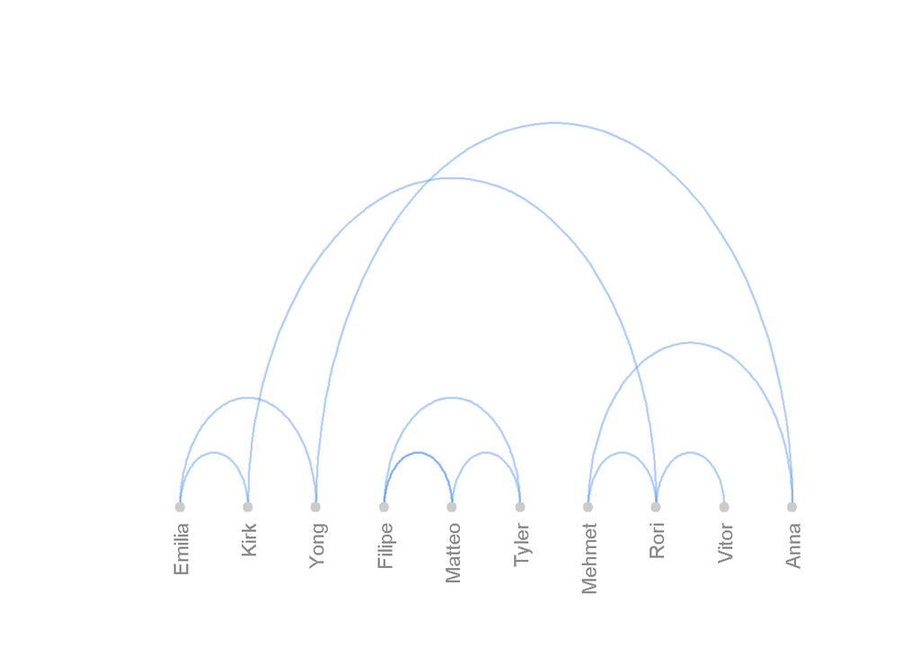

```r
lab = rbind(c("Emilia", "Kirk"), c("Emilia", "Yong"), c("Filipe", "Matteo"),
c("Filipe", "Tyler"), c("Matteo", "Filipe"), c("Matteo", "Tyler"), c("Mehmet",
"Rori"), c("Rori", "Kirk"), c("Rori", "Vitor"), c("Anna", "Mehmet"),
c("Anna", "Yong"))

arcplot(lab)
```

### Como ficou a edgelist

```
##       [,1]     [,2]
##  [1,] "Emilia" "Kirk"
##  [2,] "Emilia" "Yong"
##  [3,] "Filipe" "Matteo"
##  [4,] "Filipe" "Tyler"
##  [5,] "Matteo" "Filipe"
##  [6,] "Matteo" "Tyler"
##  [7,] "Mehmet" "Rori"
##  [8,] "Rori"   "Kirk"
##  [9,] "Rori"   "Vitor"
## [10,] "Anna"   "Mehmet"
## [11,] "Anna"   "Yong"
```

### Criando um gráfico

Se quisermos plotar nosso gráfico usando o pacote igraph(), primeiro precisamos criar um objeto “graph” com a função graph.edgelist() e, em seguida, podemos usar o método plot() padrão:

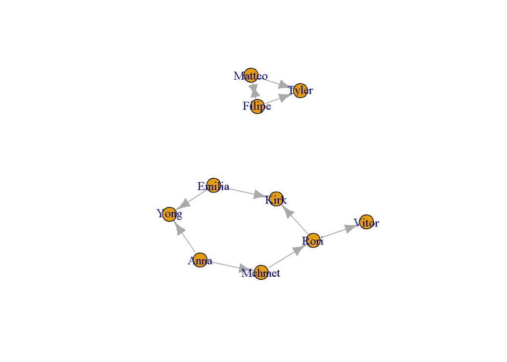

```r
# Gráfico da edgelist
glab = graph.edgelist(lab, directed = TRUE)
# plot gráfico
plot(glab)
```

### Podemos levar em consideração o grau dos nós - o grau de um nó é o número de arestas conectadas, para isso usaremos degrees():

```r
lab_degree = degree(glab)
```

```r
lab_degree
```

```
## Emilia   Kirk   Yong Filipe Matteo  Tyler Mehmet   Rori  Vitor   Anna
##      2      2      2      3      3      2      2      3      1      2
```

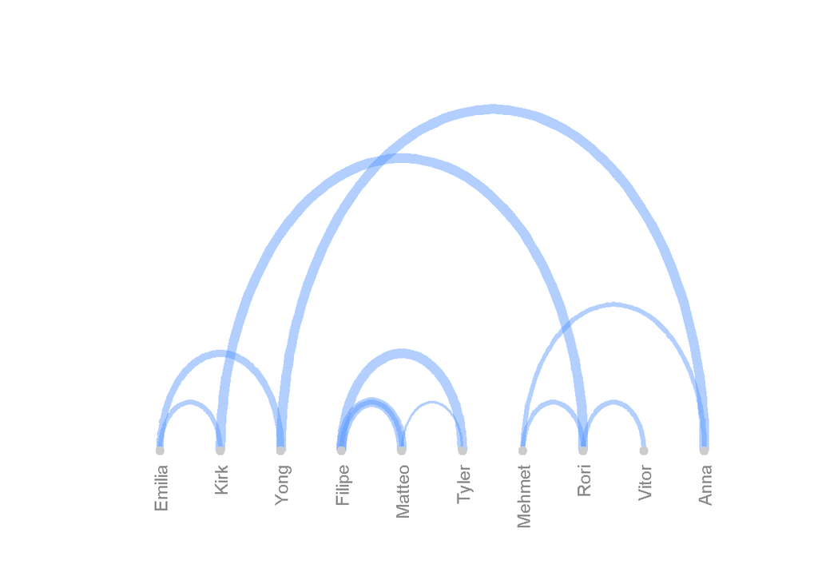

```r
arcplot(lab, lwd.arcs = l)
```

### Também podemos obter clusters dos nós usando a função clusters():

```r
gclus = clusters(glab)
```

```r
gclus
```

```
## $membership
## Emilia   Kirk   Yong Filipe Matteo  Tyler Mehmet   Rori  Vitor   Anna
##      1      1      1      2      2      2      1      1      1      1
##
## $csize
## [1] 7 3
##
## $no
## [1] 2
```

### Aplicando cores que reflitam as associações de cluster:

```r
# Definindo dois tons de azul
blues = c("#adccff", "#4272bf")
# Vetor de cores com base na associação dos clusters
cols = blues[gclus$membership]
```

### Aplicando a função arcplot()

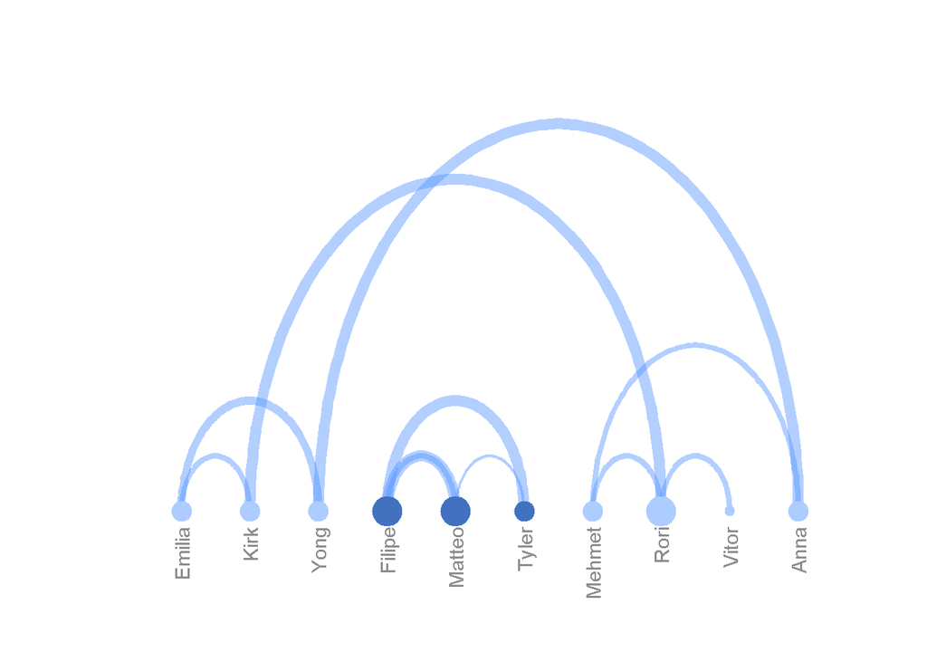

```r
arcplot(lab, lwd.arcs = l, cex.nodes = lab_degree,
col.nodes = cols)
```

### Vamos ordenar os nós de acordo com os clusters:

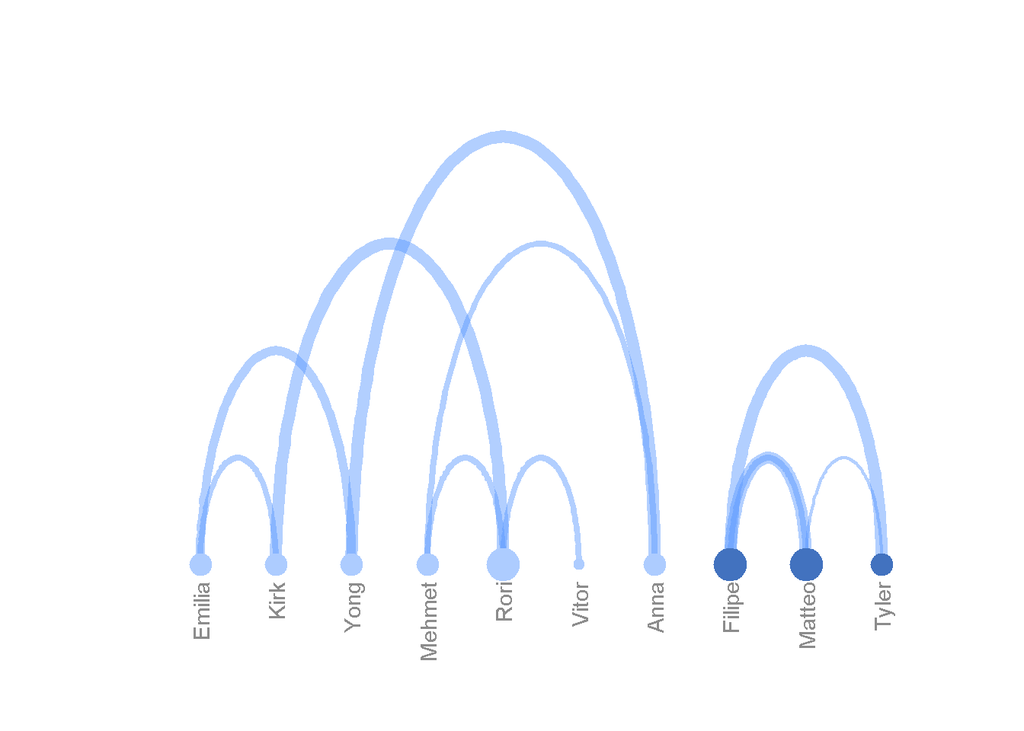

```r
arcplot(lab, lwd.arcs = l, col.nodes = cols,
        cex.nodes = lab_degree, bg.nodes = cols, ordering = order(gclus$membership))
```

### Vamos mudar o diagrama para uma orientação vertical:

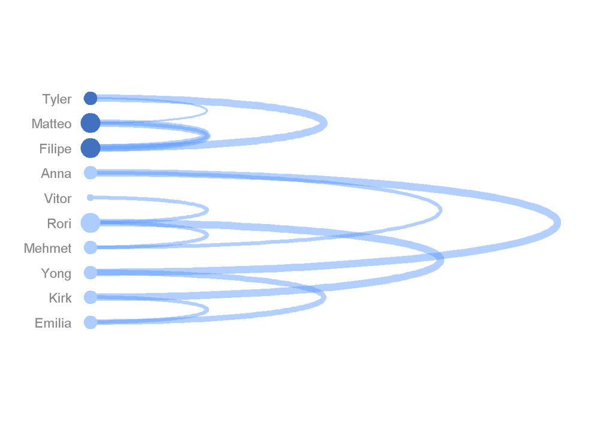

```r
arcplot(lab, lwd.arcs = l,
cex.nodes = lab_degree, col.nodes = cols, bg.nodes = cols,
show.nodes = TRUE, ordering = order(gclus$membership), horizontal = FALSE)
```